#### Nombre: Juan pablo Acero Baena c.c. 1032480625

# Regresión Lineal

## Introducción

El análisis de regresión es una de las técnicas de uso más usado para el análisis de datos con numerosas variables. Su atractivo y utilidad general son el resultado del proceso conceptualmente lógico de usar una ecuación para expresar la relación entre una variable de interés (la respuesta o dependiente) y un conjunto de variables predictoras relacionadas (o también llamadas varibles independientes o explicativas). El análisis de regresión busca, por medio de una teoría matemática de fondo, abstraer un problema de la realidad y plasmarlo en lo que llamaremos un modelo.

Esta teoría estadística de fondo de la que hablamos Se ha manisfestado en diferentes metodologías, de las cuales resaltamos el método de mínimos cuadrados y el método de máxima verosimilítud. ¿Pero en qué radica la importancia de estos? bueno, estos nos ayudan a encontrar lo que llamaremos los parámetros del modelo, los cuales son los que nos ayudan a dar respuesta al análisis del fenómeno que está detrás de esto que denominamos regresión. Pero, qué ocurre cuando nos enfrentamos a una cantidad de datos tan númerosos? bueno, aquí el problema radica en la perdida de tiempo que implica realizar el cálculo matemático de estos paramétros a mano. Ante esto, es de mucha importancia el apoyo computacional, que nos permita hacer estos cálculos de forma muy precisa y eficaz y así economizar tiempo. Algunos ejemplos de software que nos permiten hacer estos análisis son R, Python, SAS, entre otros.

El trabajo presentado en este documento abordará alguna de las metodologías aquí mencionadas aplicada a un conjunto de datos y con ayuda del sotware Python se dará respuesta al fénomeno que está detrás del modelo de regresión ajustado a estos datos.$^1$

## Breve historia

Las nociones de la regesión lineal han tenido diferentes bases a lo largo de la historia proveninentes de diferentes autores. Los primeros que empezaron a incursionar con esto fueron Gauss y legendre con el concepto de los mínimos cuadrados para ajustar los datos sobre las órbitas de cuerpos celestes. Fue en 1805 cuando Legendre hizo la primera publicación con respecto al método de mínimos cuadrados ordinarios, en la que el muestra que esta técnica de optimización busca encontrar la función (dentro de una familia) que mejor se ajusta a los datos bivariantes, de acuerdo con el criterio de mínimo error cuadrático. El problema que tenía Legendre con esto era que a pesar de que se conocían las ecuaciones funcionales de estas órbitas, los errores de medida hacía que los cálculos fuesen aproximados, generando sesgos en las estimaciones de estos estimadores de mínimos cuadrados. En 1829 Gauss fue capaz de establecer la razón por la cual este procedimiento es muy adecuado desde el punto de vista estadístico, mediante lo que hoy se conoce como teorema de Gauss-Markov, que muestra que los estimadores obtenidos con este método son insesgados.$^2$

## Planteamiento del algoritmo

[figure not shown]

El modelo de regresión múltiple EI modelo que se plantea en regresión mültiple es el siguiente:

$y_{i}=\beta_{0}+\beta_{1} x_{1 i}+\beta_{2} x_{2 i}+\ldots+\beta_{k} x_{k i}+\epsilon_{i}$

$$ \mathbf{y}=\mathbf{X} \beta+\varepsilon $$

en donde $$ \begin{array}{l} \mathbf{y}=\left[\begin{array}{c} y_{1} \\ y_{2} \\ \vdots \\ y_{n} \end{array}\right], & \mathbf{X}=\left[\begin{array}{ccccc} 1 & x_{11} & x_{12} & \cdots & x_{1 k} \\ 1 & x_{21} & x_{22} & \cdots & x_{2 k} \\ \vdots & \vdots & \vdots & & \vdots \\ 1 & x_{n 1} & x_{n 2} & \cdots & x_{n k} \end{array}\right] \\ \beta & =\left[\begin{array}{c} \beta_{0} \\ \beta_{1} \\ \vdots \\ \beta_{k} \end{array}\right], & \varepsilon=\left[\begin{array}{c} \varepsilon_{1} \\ \varepsilon_{2} \\ \vdots \\ \varepsilon_{n} \end{array}\right] \end{array} $$

Las ecuaciones anteriores son las ecuaciones normales de mínimos cuadrados. Son la forma matricial de la presentación escalar, ecuaciones.

Para resolver las ecuaciones normales se multiplican ambos lados de por la inversa de $\mathbf{X}^{\prime} \mathbf{X}$. Así, el estimador de $\beta$ por mínimos cuadrados es $$ \hat{\beta}=\left(\mathbf{X}^{\prime} \mathbf{X}\right)^{-1} \mathbf{X}^{\prime} \mathbf{y} $$ siempre y cuando exista la matriz inversa $\left(\mathbf{X}^{\prime} \mathbf{X}\right)^{-1}$. La matriz $\left(\mathbf{X}^{\prime} \mathbf{X}\right)^{-1}$ siempre existe si los regresores son linealmente independientes, esto es, si ninguna columna de la matriz $\mathbf{X}$ es una combinación lineal de las demás columnas.

Es fácil de ver que la forma matricial de las ecuaciones normales es idéntica a la forma escalar. Al escribir con detalle se obtiene

$$ \left[\begin{array}{ccccc} n & \sum_{i=1}^{n} x_{i 1} & \sum_{i=1}^{n} x_{i 2} & \cdots & \sum_{i=1}^{n} x_{i k} \\ \sum_{i=1}^{n} x_{i 1} & \sum_{i=1}^{n} x_{i 1}^{2} & \sum_{i=1}^{n} x_{i 1} x_{i 2} & \cdots & \sum_{i=1}^{n} x_{i 1} x_{i k} \\ \vdots & \vdots & \vdots & & \vdots \\ \sum_{i=1}^{n} x_{i k} & \sum_{i=1}^{n} x_{i k} x_{i 1} & \sum_{i=1}^{n} x_{i k} x_{i 2} & \cdots & \sum_{i=1}^{n} x_{i k}^{2} \end{array}\right]\left[\begin{array}{c} \hat{\beta}_{0} \\ \hat{\beta}_{1} \\ \vdots \\ \hat{\beta}_{k} \end{array}\right]=\left[\begin{array}{c} \sum_{i=1}^{n} y_{i} \\ \sum_{i=1}^{n} x_{i 1} y_{i} \\ \vdots \\ \sum_{i=1}^{n} x_{i k} y_{i} \end{array}\right] $$

El modelo ajustado de regresión que corresponde a los niveles de las variables regresoras $\mathbf{x}^{\prime}=\left[1, x_{1}, x_{2}, \ldots, x_{k}\right]$ es $$ \hat{y}=\mathbf{x}^{\prime} \hat{\beta}=\hat{\beta}_{0}+\sum_{j=1}^{k} \hat{\beta}_{j} x_{j} $$ El vector de valores ajustados $\hat{y}_{i}$ que corresponden a los valores observados $y_{i}$ es $$ \hat{y}=\mathbf{X} \hat{\beta}=\mathbf{X}\left(\mathbf{X}^{\prime} \mathbf{X}\right)^{-1} \mathbf{X}^{\prime} \mathbf{y}=\mathbf{H} \mathbf{y} $$ La $n \times n$ es la matriz $\mathbf{H}=\mathbf{X}\left(\mathbf{X}^{\prime} \mathbf{X}\right)^{-1} \mathbf{X}^{\prime}$ se suele llamar matriz de sombrero. Aplica el vector de valores observados en un vector de valores ajustados. La matriz de sombrero y sus propiedades desempeñan un papel central en el análisis de regresión.

La diferencia entre el valor observado $y_{i} \mathrm{y}$ el valor ajustado $\hat{y}_{i}$ correspondiente es el residual $e_{i}=y_{i}-\hat{y}_{i} .$ Los $n$ residuales se pueden escribir cómodamente con notación matricial como sigue: $$ \mathbf{e}=\mathbf{y}-\hat{y} $$ Hay otras maneras de expresar el vector de residuales e, que pueden ser útiles, como $$ \mathbf{e}=\mathbf{y}-\mathbf{X} \hat{\beta}=\mathbf{y}-\mathbf{H} \mathbf{y}=(\mathbf{I}-\mathbf{H}) \mathbf{y} $$ Teniendo en cuenta la teoría de mostrada atrás se usará statmodels para poder ajustar un modelo de regresión lineal al conjunto de datos que se muestra a continuación.

## Ejemplo práctico

```python
import pandas as pd
import numpy as np
import seaborn as sns
import statsmodels.api as sm
from IPython.display import Image
from IPython.core.display import HTML
```

```python
data= pd.read_excel("Base de datos proyecto.xlsx")
data
```

|  | Sexo | Años | Tamaño | Peso |
| --- | --- | --- | --- | --- |
| 0 | 0 | 0 | 4512 | 1530 |
| 1 | 0 | 0 | 3738 | 1297 |
| 2 | 0 | 0 | 4261 | 1335 |
| 3 | 0 | 0 | 3777 | 1282 |
| 4 | 0 | 0 | 4177 | 1590 |
| ... | ... | ... | ... | ... |
| 232 | 1 | 1 | 3214 | 1110 |
| 233 | 1 | 1 | 3394 | 1215 |
| 234 | 1 | 1 | 3233 | 1104 |
| 235 | 1 | 1 | 3352 | 1170 |
| 236 | 1 | 1 | 3391 | 1120 |

237 rows × 4 columns

### Objetivo:

- Determinar el peso promedio del cerebro de las personas de Reino Unido haciendo uso del análisis de regresión.

### Justificación:

- La información generada luego del análisis estadístico del fenómeno de interés podría proporcionar un apoyo para la realización de otros estudios con fines médicos, sociales etc. Sin embargo, la elaboración de este trabajo sólo abarca fines pedagógicos en los que se pone en práctica algunos conceptos del análisis de regresión.

### Descripción de las variables

[figure not shown]

### Gráficos de dispersión

#### Tamaño vs peso según rango de edad

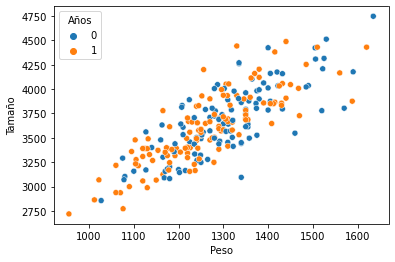

```python
sns.scatterplot(data=data, x="Peso", y="Tamaño", hue="Años")
```

#### Tamaño vs peso según sexo

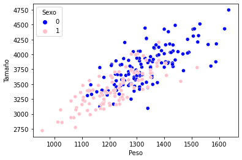

```python
sns.scatterplot(data=data, x="Peso", y="Tamaño", hue="Sexo", palette=["blue", "pink"])
```

### Descripción del modelo

$$ \text { Modelo I: } y_{k}=\beta_{1}+\beta_{2} x_{2 k}+\beta_{3} x_{3 k}+\beta_{4} x_{4 k} \\ $$$$ y_{k}=\text { Peso del cerebro del individuo } k \text { dado en gramos } \\ x_{2 k}=\left\{\begin{array}{l} 1 \text { si el individuo } k \text { es de género femenino } \\ 0 \text { si el individuo } k \text { es de género masculino } \\ \end{array}\right.\\ x_{3 k}=\left\{\begin{array}{l} 1 \text { si el individuo } k \text { tiene más de 46 años} \\ 0 \text { si el individuo } k \text { tiene entre 20 y 46 años}\\ \end{array}\right. \\ x_{4 k}= \text{Tamaño del cráneo del individuo k en } 𝑐𝑚^3 $$

### Resultado del modelo

```python
data=sm.tools.tools.add_constant(data, prepend=True, has_constant='skip')
fit = sm.OLS(data["Peso"], data[["const", "Sexo", "Años", "Tamaño"]]).fit()
print(fit.summary())
```

```
                            OLS Regression Results
==============================================================================
Dep. Variable:                   Peso   R-squared:                       0.653
Model:                            OLS   Adj. R-squared:                  0.648
Method:                 Least Squares   F-statistic:                     146.0
Date:                Sat, 13 Mar 2021   Prob (F-statistic):           2.94e-53
Time:                        20:28:43   Log-Likelihood:                -1345.7
No. Observations:                 237   AIC:                             2699.
Df Residuals:                     233   BIC:                             2713.
Df Model:                           3
Covariance Type:            nonrobust
==============================================================================
                 coef    std err          t      P>|t|      [0.025      0.975]
------------------------------------------------------------------------------
const        418.0511     58.748      7.116      0.000     302.305     533.797
Sexo         -22.5433     11.058     -2.039      0.043     -44.329      -0.757
Años         -23.9684      9.481     -2.528      0.012     -42.647      -5.290
Tamaño         0.2442      0.015     16.212      0.000       0.215       0.274
==============================================================================
Omnibus:                        7.989   Durbin-Watson:                   1.922
Prob(Omnibus):                  0.018   Jarque-Bera (JB):                8.255
Skew:                           0.357   Prob(JB):                       0.0161
Kurtosis:                       3.571   Cond. No.                     4.66e+04
==============================================================================

Notes:
[1] Standard Errors assume that the covariance matrix of the errors is correctly specified.
[2] The condition number is large, 4.66e+04. This might indicate that there are
strong multicollinearity or other numerical problems.
```

### Interpretación de parámetros

- $𝛽_1$: Si es posible un individuo hombre que se encuentre entre 20 y 46 años con tamaño craneal de 0 $𝑐𝑚^3$, el peso promedio de su cerebro será de 418.0511 gramos.
- $𝛽_2$: Si se compara el peso del cerebro de un hombre y una mujer con el mismo rango de edad y el mismo tamaño del cráneo se espera que el peso del cerebro de la mujer sea 22.5432 gramos menor que el del hombre.
- $𝛽_3$: Si se compara el peso del cerebro de un individuo independientemente de su sexo que tiene entre 20 y 46 años y uno que tenga más de 46 años con el mismo tamaño del cráneo se espera que el peso del cerebro del individuo que tiene entre 20 y 46 años sea 23.96845 gramos mayor que el que tiene más de 46 años.
- $𝛽_4$: Si se compara el peso del cerebro de un individuo independientemente de su sexo y del rango de edad en que se encuentre, se espera que por cada $cm^3$ adicional en el tamaño de la cabeza el peso en promedio aumente 0.24421 gramos.
- $𝜎$: La distancia promedio entre el peso en gramos del cerebro para un individuo k y el valor promedio del mismo para los individuos con los mismos atributos que el en tamaño de la cabeza, si pertenece al rango de edad de entre 20 y 46 años o más de 46 años, y si es hombre o mujer es de 71.36

## Bibliografía

1. Montgomery, Douglas C, et al. Introduction to Linear Regression Analysis. New York, Wiley, 2001. 2.[Algunas notas históricas sobre la correlación y regresión y su uso en el aula, Antonio Estepa Castro](https://core.ac.uk/download/pdf/20343739.pdf)
2. Colaboradores de los proyectos Wikimedia. “Regresión Lineal.” Wikipedia.org, Wikimedia Foundation, Inc., 20 Feb. 2006, es.wikipedia.org/wiki/Regresi%C3%B3n_lineal#Historia. Accessed 13 Mar. 2021.
3. Gladstone, Reginald J. “A Study of the Relations of the Brain to the Size of the Head.” Biometrika, vol. 4, no. 1/2, 1905, pp. 105–123, www.jstor.org/stable/2331533, 10.2307/2331533. Accessed 13 Mar. 2021.